# Linear Regression Lab

Christopher Lovell

Saturday, March 14, 2015

```r
library(MASS)
library(ISLR)
?Boston
```

```
## starting httpd help server ... done
```

```r
str(Boston)
```

```
## 'data.frame':    506 obs. of  14 variables:
##  $ crim   : num  0.00632 0.02731 0.02729 0.03237 0.06905 ...
##  $ zn     : num  18 0 0 0 0 0 12.5 12.5 12.5 12.5 ...
##  $ indus  : num  2.31 7.07 7.07 2.18 2.18 2.18 7.87 7.87 7.87 7.87 ...
##  $ chas   : int  0 0 0 0 0 0 0 0 0 0 ...
##  $ nox    : num  0.538 0.469 0.469 0.458 0.458 0.458 0.524 0.524 0.524 0.524 ...
##  $ rm     : num  6.58 6.42 7.18 7 7.15 ...
##  $ age    : num  65.2 78.9 61.1 45.8 54.2 58.7 66.6 96.1 100 85.9 ...
##  $ dis    : num  4.09 4.97 4.97 6.06 6.06 ...
##  $ rad    : int  1 2 2 3 3 3 5 5 5 5 ...
##  $ tax    : num  296 242 242 222 222 222 311 311 311 311 ...
##  $ ptratio: num  15.3 17.8 17.8 18.7 18.7 18.7 15.2 15.2 15.2 15.2 ...
##  $ black  : num  397 397 393 395 397 ...
##  $ lstat  : num  4.98 9.14 4.03 2.94 5.33 ...
##  $ medv   : num  24 21.6 34.7 33.4 36.2 28.7 22.9 27.1 16.5 18.9 ...
```

## Simple Linear Regression

We want to predict median house price, `medv`, using the other 13 predictors.

Start by fitting a linear regression, with `medv` as the response and lstat (‘lower status of the population, percent’) as the predictor.

```r
lm.fit=lm(medv~lstat,data=Boston)
summary(lm.fit)
```

```
##
## Call:
## lm(formula = medv ~ lstat, data = Boston)
##
## Residuals:
##     Min      1Q  Median      3Q     Max
## -15.168  -3.990  -1.318   2.034  24.500
##
## Coefficients:
##             Estimate Std. Error t value Pr(>|t|)
## (Intercept) 34.55384    0.56263   61.41   <2e-16 ***
## lstat       -0.95005    0.03873  -24.53   <2e-16 ***
## ---
## Signif. codes:  0 '***' 0.001 '**' 0.01 '*' 0.05 '.' 0.1 ' ' 1
##
## Residual standard error: 6.216 on 504 degrees of freedom
## Multiple R-squared:  0.5441, Adjusted R-squared:  0.5432
## F-statistic: 601.6 on 1 and 504 DF,  p-value: < 2.2e-16
```

The coefficients and confidence intervals for the fit are accessed through methods in the `stats` library.

```r
coef(lm.fit)
```

```
## (Intercept)       lstat
##  34.5538409  -0.9500494
```

```r
confint(lm.fit)
```

```
##                 2.5 %     97.5 %
## (Intercept) 33.448457 35.6592247
## lstat       -1.026148 -0.8739505
```

The `predict()` function can be used to generate confidence and prediction intervals for a given value of `lstat`. Both are centered at the same point, but give different error margins.

```r
predict(lm.fit,data.frame(lstat=c(5,10,15)),interval = "confidence")
```

```
##        fit      lwr      upr
## 1 29.80359 29.00741 30.59978
## 2 25.05335 24.47413 25.63256
## 3 20.30310 19.73159 20.87461
```

```r
predict(lm.fit,data.frame(lstat=c(5,10,15)),interval = "prediction")
```

```
##        fit       lwr      upr
## 1 29.80359 17.565675 42.04151
## 2 25.05335 12.827626 37.27907
## 3 20.30310  8.077742 32.52846
```

The plot below shows the values against the regression line.

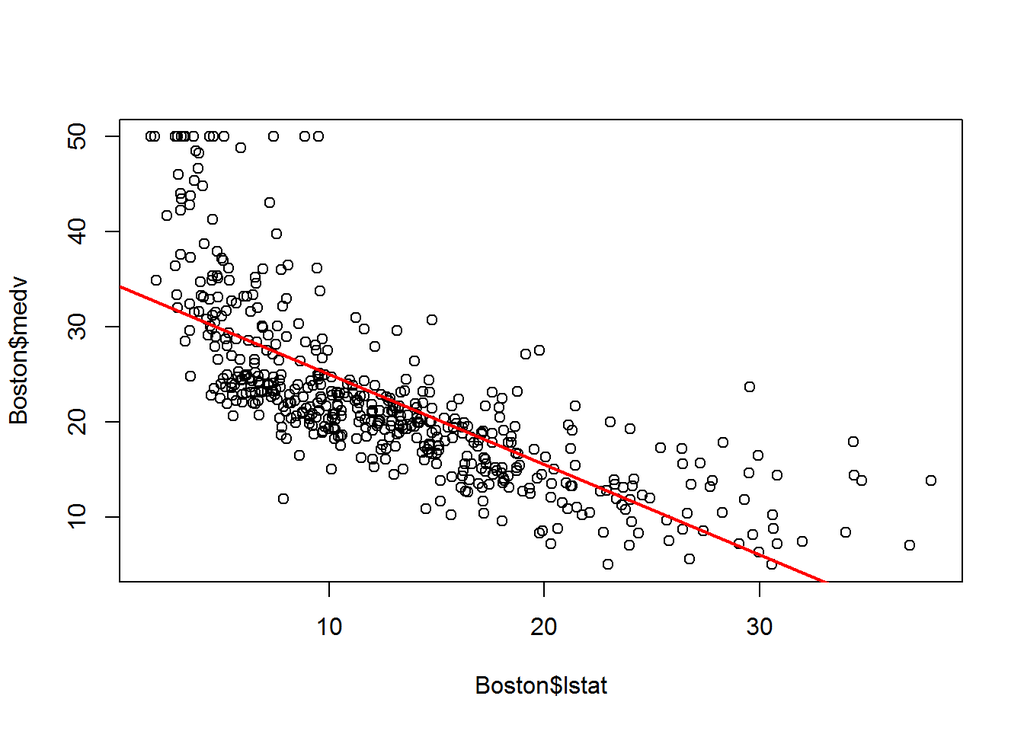

```r
plot(Boston$lstat,Boston$medv,pch=1)
abline(lm.fit,lwd=2,col="red")
```

Below are diagnostic plots, including a plot of the residuals. Note fit is smoothed to residual points, and is not the linear regression fit `lm.fit`.

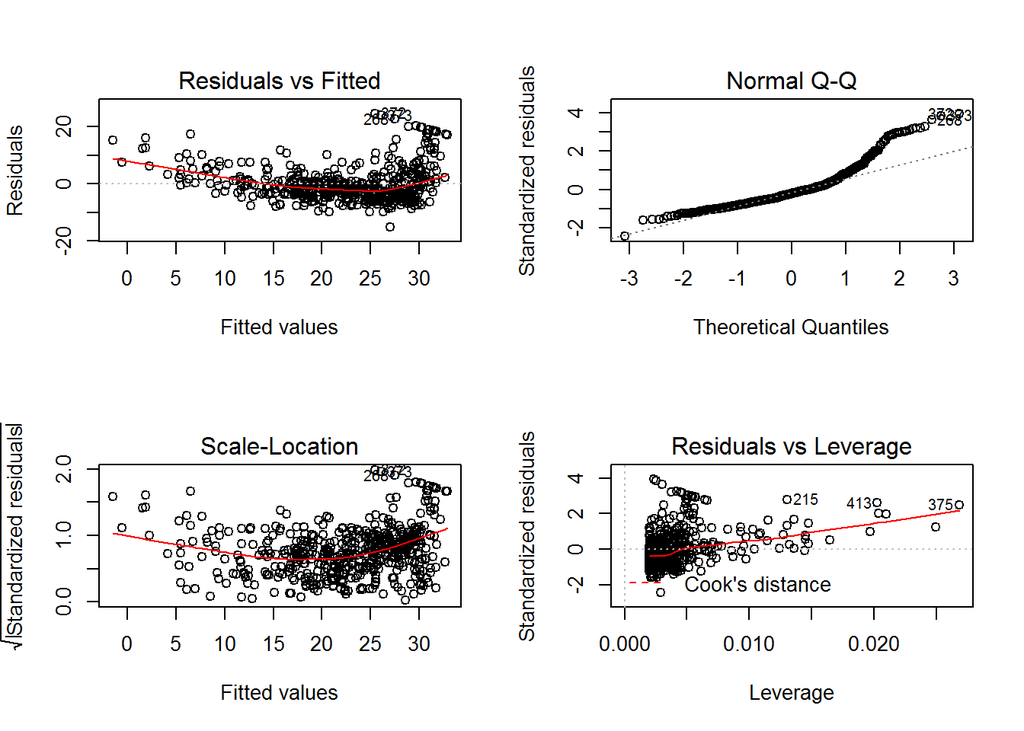

```r
par(mfrow=c(2,2))
plot(lm.fit)
```

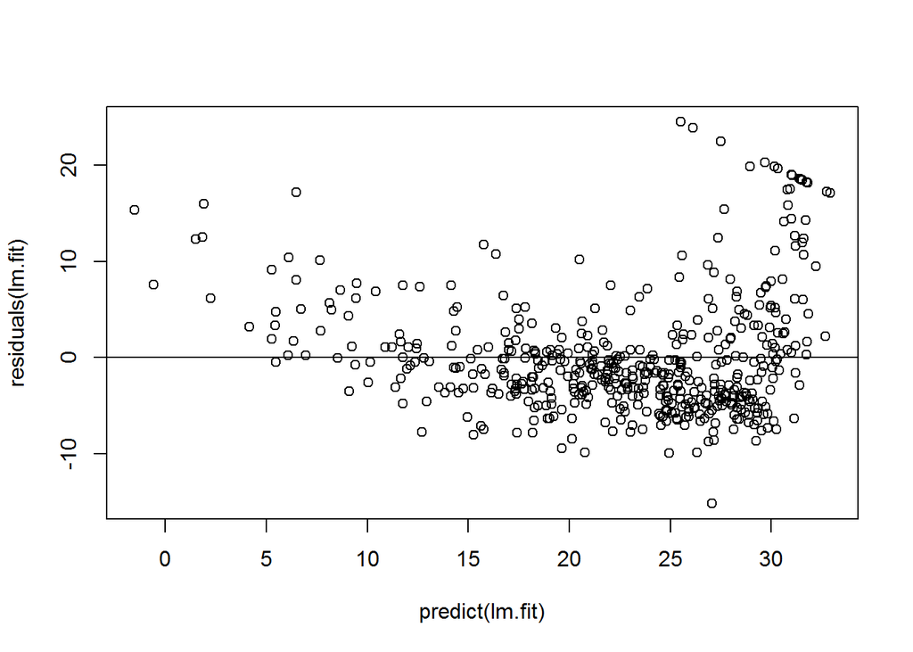

```r
plot(predict(lm.fit),residuals(lm.fit))
abline(0,0)
```

Studentized residuals, shown below, are residuals divided by their estiated standard error.

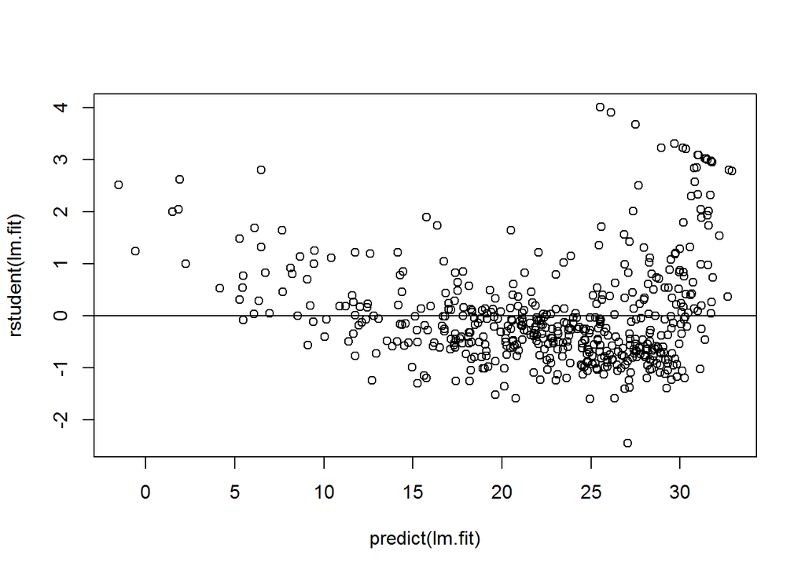

```r
plot(predict(lm.fit),rstudent(lm.fit))
abline(0,0)
```

Leverage measures those values with abnormal predictor values. These tend to have a large effect on the least squares fit.

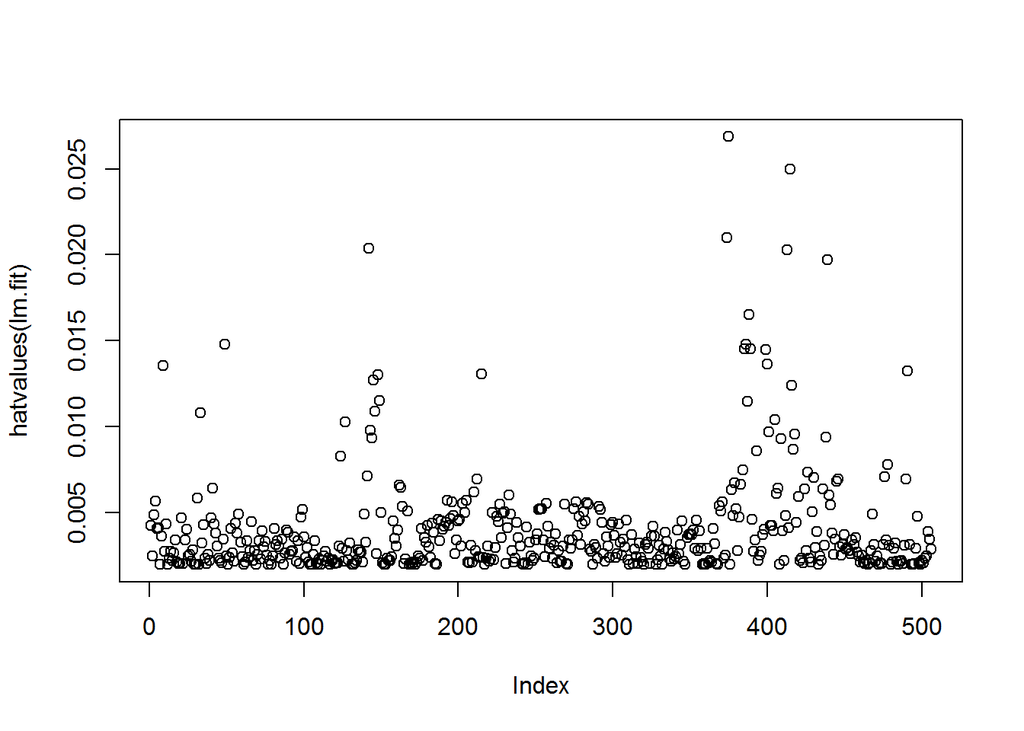

```r
plot(hatvalues(lm.fit))
```

## Multiple Linear Regression

```r
lm.fit.mult=lm(medv~lstat+age,data=Boston)
summary(lm.fit)
```

```
##
## Call:
## lm(formula = medv ~ lstat, data = Boston)
##
## Residuals:
##     Min      1Q  Median      3Q     Max
## -15.168  -3.990  -1.318   2.034  24.500
##
## Coefficients:
##             Estimate Std. Error t value Pr(>|t|)
## (Intercept) 34.55384    0.56263   61.41   <2e-16 ***
## lstat       -0.95005    0.03873  -24.53   <2e-16 ***
## ---
## Signif. codes:  0 '***' 0.001 '**' 0.01 '*' 0.05 '.' 0.1 ' ' 1
##
## Residual standard error: 6.216 on 504 degrees of freedom
## Multiple R-squared:  0.5441, Adjusted R-squared:  0.5432
## F-statistic: 601.6 on 1 and 504 DF,  p-value: < 2.2e-16
```

To fit all predictors use the `.` notation

```r
lm.fit.mult=lm(medv~.,data=Boston)
```

```r
summary(lm.fit.mult)$r.sq
```

```
## [1] 0.7406427
```

```r
summary(lm.fit.mult)$sigma
```

```
## [1] 4.745298
```

The `car` package contains the `vif()` function, which can be used to calculate variance inflation factors for each predictor. The variance inflation factor (VIF is a measure of collinearity in a multiple regression. A correlation matrix allows you to assess collinearity between two predictors, but if there exists collinearity between multiple predictors this won’t show in the matrix.

```r
library(car)
vif(lm.fit.mult)
```

```
##     crim       zn    indus     chas      nox       rm      age      dis
## 1.792192 2.298758 3.991596 1.073995 4.393720 1.933744 3.100826 3.955945
##      rad      tax  ptratio    black    lstat
## 7.484496 9.008554 1.799084 1.348521 2.941491
```